# Names as Data

The field every record about a person carries, and the three jobs it is asked to do

Democracy’s Data

Last updated September 13, 2026 at 10:53a EDT

Every administrative record about a person carries a name, and in many it is the only description there is. The voter registration has one, and so do the campaign filing, the court docket, the jury questionnaire and the traffic stop. None was written to describe anybody, so most hold no age, no sex and no race. They hold a name, because a clerk had to write something in the box.

So the name is asked to do work, and always the same three jobs:

1. **Identify.** Pick this person out from everybody else.
2. **Link.** Two records carry the same name, so they are the same person.
3. **Infer.** The file records no sex or race, so guess them from the name.

Each is a claim about how names are spread across the country, and nobody holding a voter file can check it from the voter file. Two administrative tabulations can. How far a name carries decides whether you are matched to the right registration, flagged as somebody else on a purge list, or counted into a disparity a court must rule on.

## The test

The first source is the Census Bureau’s tabulation of the name field in the 2020 census. It appeared in April 2026 as *Frequently Occurring First Names in the 2020 Census* and its companion for last names, downloadable as spreadsheets at https://www.census.gov/topics/population/genealogy/data/2020_names.html.[^1] Together they hold 53,615 first names covering 302,031,536 people, and 156,621 surnames covering 298,898,231.

The second is the Social Security Administration’s national name file: one plain text table per year of birth from 1880 to 2025, three columns wide, name and sex and count (https://www.ssa.gov/oact/babynames/limits.html).

These two are the right instruments because they count the field itself. Every other file in this book has a name column and no way to say how common a name is, which is what all three jobs depend on. Neither was made to study names. The agency writes down a name and a birth year because it cannot issue a card otherwise; the Bureau counts residents. Both tabulations are by-products, the kind of record Section III is about.

## The data

Twenty-six tables come out of this chapter, two files’ worth of source: the 2020 Census surname tables, and the Social Security Administration’s name-by-year registrations back to 1880. Sizes are rows by columns, read off the files.

| Table | What it holds | Size |
| --- | --- | --- |
| `top25.csv` | The most common first names and last names, ranked, with count and share. | 50 × 5 |
| `cover.csv` | What share of the country the top 10, top N first and last names cover. | 4 × 3 |
| `curve.csv` | The cumulative-share curve: rank against running percentage of the population, for first and last names. | 421 × 4 |
| `collision.csv` | Birthday-problem probabilities: how likely two people share a name, from the same counts. | 4 × 3 |
| `concentration.csv` | How many names the file actually publishes against how many people that leaves in the unpublished residual, with information-theoretic bounds on what a name still reveals. | 2 × 12 |
| `race_info.csv` | How much a first or last name narrows down a person’s race: bits of uncertainty removed, and how many names cross 90% modal accuracy. | 2 × 10 |
| `race_extremes.csv` | The single most race-concentrated first name and last name in each of the six published race/ethnicity groups. | 12 × 6 |
| `explore_first.csv` | Every published first name with its full race and sex breakdown – the table the name-lookup figure reads. | 2,000 × 11 |
| `explore_last.csv` | The same, for last names, without the sex columns the Bureau does not publish for surnames. | 2,000 × 10 |
| `both_ways.csv` | Names that are common as both a first name and a last name, with each count side by side. | 12 × 3 |
| `disagreement_top.csv` | The names whose count differs most between the Bureau’s sex-by-name table and its race-by-name table – two tables about the same names that do not perfectly agree. | 10 × 5 |
| `disagreement.csv` | That same sex-table-vs-race-table gap, as a distribution: how many names differ by how much. | 6 × 2 |
| `negatives.csv` | How often the Bureau’s privacy noise pushed a published cell below zero, by table – the sign of the disclosure-avoidance system at work. | 2 × 8 |
| `negatives_top.csv` | The specific names hit hardest by a negative cell: published counts next to the Bureau’s own noise-corrected research file. | 8 × 6 |
| `unisex.csv` | Names closest to an even sex split, ranked by how close to 50/50 they fall. | 12 × 4 |
| `sex_bands.csv` | How many names cross each threshold of sex skew – the distribution unisex.csv is drawn from. | 5 × 4 |
| `sex_scatter.csv` | One row per name: total people and percent female, the scatter the sex-balance figure plots. | 1,394 × 3 |
| `ssa_totals.csv` | Every name in the Social Security birth-registration file since 1880, against its 2020 census count and rank – the table linking the two eras. | 1,090 × 7 |
| `ssa_alexa.csv` | One name’s (Alexa’s) year-by-year SSA registrations, rank and cumulative births – the worked example of a name’s rise and fall. | 146 × 6 |
| `ssa_births.csv` | Total SSA-registered births by year and sex, back to 1880 – the denominator every other SSA table is a share of. | 146 × 4 |
| `ssa_coverage.csv` | How completely SSA birth registration actually covers births, by year – registered against the true count, where known. | 4 × 4 |
| `ssa_explore.csv` | Every published name’s year-by-year SSA count by sex – the raw series the browser’s name explorer reads. | 128,658 × 4 |
| `ssa_newcomers.csv` | Names with no SSA registrations before a given year: when they first appear, and how many people carry them since. | 10 × 4 |
| `ssa_risers.csv` | Names whose frequency has climbed most since an earlier peak, then and now, with the peak year. | 10 × 7 |
| `ssa_shock.csv` | Names whose SSA registrations spiked in a specific year, tied to the event that year is named for. | 144 × 5 |
| `ssa_vs_census.csv` | For a name, SSA births carried forward to 2020 against the actual 2020 census count – how much of a birth cohort the census still finds. | 5 × 5 |

Two more files here are not data about names at all – they are how this chapter checked its own work: `facts.csv`, the individual numbers the text above quotes, and `checks.csv`, the arithmetic verified before anything was drawn.

Each row of a census table is one name with a rank and a count. The first-name table adds `pct_female`; both add six shares, `pct_white`, `pct_black`, `pct_aian`, `pct_asian`, `pct_twoplus` and `pct_hispanic`. That is the whole record: no age, no state, no way to join a first name to a surname.

| Table | Names published | People covered | Share of the 2020 census | Swept into ALL OTHER NAMES |
| --- | --- | --- | --- | --- |
| First names | 53,615 | 302,031,536 | 91.1% | 18,794,706 |
| Last names | 156,621 | 298,898,231 | 90.2% | 36,257,637 |

Three things there decide what can be asked of it. **A name is listed only if about a hundred people had it**, and everyone else, 18,794,706 people by first name, goes into a final row called ALL OTHER NAMES with an empty rank. **A first name was recorded for 91.1% of those counted.** The other 29,417,745 are not a random draw; they sit wherever the census fell back on administrative records or a neighbour’s answer. **And the counts have had noise added to them on purpose.** The Bureau’s **disclosure avoidance** system nudges every published 2020 figure by a small random amount so that no individual can be picked out of a table,[^2] and the name tables went through it like everything else.

Before any of it could be counted, the field had to be made. The unedited returns held about 6.0 million distinct first names, and editing removed roughly 800,000.[^3] The largest problem was not misspelling. Over ten million entries were not names at all: PERSON, CHILD, DAUGHTER, TENANT, MRS SMITH. Left alone, PERSON would have been one of the country’s most common first names.

Two repairs travel into every other file you will ever join. Punctuation, numbers, spaces and suffixes were removed, so MICHAEL, MI CH AEL and MICHAEL III all count as MICHAEL. That is right for a frequency table, and it is what a matching program has to do too, which most do not. And Spanish names holding Ñ reached the Bureau with the character already turned into a question mark, so PEÑA is published as PENA. The damage happened upstream, and the repair is a second decision on top of it.

The noise was run independently into the sex table and the race table, so **49,089 of 53,615 first names carry a different total in the two.** Neither is wrong. No fact about how many Americans are named MICHAEL survives publication, because publication is what added the noise.

| Rank | Name | In the sex table | In the race table | Gap |
| --- | --- | --- | --- | --- |
| 1 | MICHAEL | 3,476,721 | 3,476,715 | 6 |
| 2 | JOHN | 3,125,123 | 3,125,114 | 9 |
| 3 | JAMES | 2,996,421 | 2,996,420 | 1 |
| 4 | DAVID | 2,813,017 | 2,813,019 | -2 |
| 5 | ROBERT | 2,759,339 | 2,759,332 | 7 |
| 6 | WILLIAM | 2,240,114 | 2,240,112 | 2 |
| 7 | MARY | 1,768,343 | 1,768,337 | 6 |
| 8 | MARIA | 1,652,966 | 1,652,964 | 2 |
| 9 | DANIEL | 1,607,193 | 1,607,193 | 0 |
| 10 | JOSEPH | 1,600,667 | 1,600,664 | 3 |

The Social Security file has different limits. It counts card applications by the birth year the applicant gave, and drops any name given to fewer than five babies in a year. Cards were first issued in 1936, so anyone born earlier appears only if they lived long enough to apply.

> **Before you read on, commit to a number.** The census publishes 156,621 surnames. **How many of them, the most common ones, would you need to cover half of everybody in the file?** Write it down, then do the same for first names, of which there are 53,615.

## What it says about democracy

**The first job is to identify, and a name is a distribution rather than a label.**

| Rank | First name | People | Last name | People |
| --- | --- | --- | --- | --- |
| 1 | MICHAEL | 3,476,721 | SMITH | 2,369,644 |
| 2 | JOHN | 3,125,123 | JOHNSON | 1,858,234 |
| 3 | JAMES | 2,996,421 | WILLIAMS | 1,561,395 |
| 4 | DAVID | 2,813,017 | BROWN | 1,386,083 |
| 5 | ROBERT | 2,759,339 | JONES | 1,383,250 |
| 6 | WILLIAM | 2,240,114 | GARCIA | 1,149,510 |
| 7 | MARY | 1,768,343 | MILLER | 1,129,186 |
| 8 | MARIA | 1,652,966 | RODRIGUEZ | 1,085,838 |
| 9 | DANIEL | 1,607,193 | DAVIS | 1,074,448 |
| 10 | JOSEPH | 1,600,667 | MARTINEZ | 1,039,848 |

It takes 317 first names to cover half the country, and 2,412 surnames.

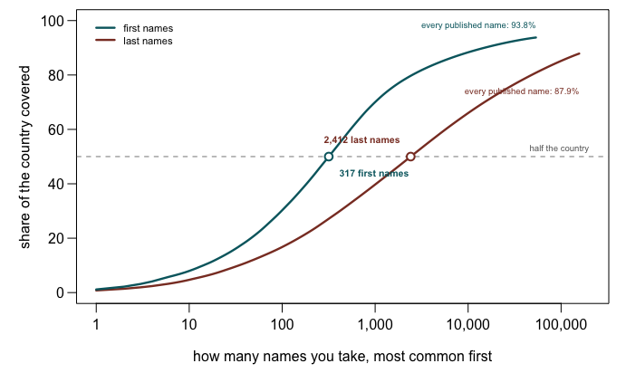

**Figure 1. How much of the country the most common names cover.** Rank runs along the bottom on a log scale, so the first thousand names and the hundred-thousandth are both readable. A cumulative curve fits the question, which is not what one name is worth but how fast coverage piles up. Neither curve reaches the top, and that is the threshold rather than a drawing error: every published first name covers only 93.8% of the file, every published surname 87.9%.

| The most common | Of first names | Of last names |
| --- | --- | --- |
| 10 names | 8.0% | 4.7% |
| 100 names | 30.3% | 16.8% |
| 1,000 names | 70.0% | 39.7% |
| 10,000 names | 88.3% | 66.0% |

**First names are the more concentrated of the two, and by a lot.** A thousand first names cover 70.0% of Americans where a thousand surnames cover 39.7%. That runs against the intuition that first names are where individuality lives, and the cause is plain. A surname is inherited from a stock the country’s whole immigration history filled up, and a first name is chosen from fashion, a much smaller menu.

**The second job is to link, and the number underneath it is small.**

| Two random Americans | Chance |
| --- | --- |
| two people share a first name | 1 in 634 |
| two people share a last name | 1 in 1,911 |
| two people share both, if the two are unrelated | 1 in 1,212,277 |
| two people share both, allowing correlation through race | 1 in 1,082,518 |

Pick two Americans at random. The chance they share a first name is one in 634, found by adding up, name by name, the chance that both drew that name; the chance they share a surname is one in 1,911. If the two halves of a name had nothing to do with each other, the chance of sharing both would be the two multiplied: 634 × 1,911 ≈ 1,212,277. So a first name and a surname together are worth about **one in 1,212,277**. That is the figure a matching program quietly relies on, and the multiplying step is legitimate only if a first name tells you nothing about a surname, which it obviously does. A floor on the error can be measured: let the two halves be related only through the six race categories the census publishes, so that a GARCIA is likelier to be a JOSE than a surname picked at random, and a shared full name gets 12% more likely. The real correlation runs through national origin and generation, which is why NGUYEN and GARCIA do not draw first names from the same pot.

Each is the chance for **one pair of people**, not the chance of a match somewhere in a list, which depends on how long the list is. That is the false matches brief.

| Name | As a first name | As a last name |
| --- | --- | --- |
| RUSSELL | 202,735 | 211,729 |
| KIM | 246,384 | 274,068 |
| GARRETT | 116,551 | 102,634 |
| MORGAN | 235,724 | 276,366 |
| DEAN | 132,116 | 109,762 |
| RAY | 107,593 | 130,289 |
| SPENCER | 106,323 | 135,510 |
| GRANT | 109,200 | 139,862 |
| HARPER | 92,376 | 119,191 |
| ROSE | 196,309 | 149,763 |
| OLIVER | 146,493 | 109,817 |
| COLE | 134,580 | 187,989 |

The two fields are not even distinct. 14,926 names appear in both tables, and **75.1% of Americans have a first name that is also somebody’s surname**. That is why a swapped-column bug is so hard to see. Exchange `first` and `last` for part of a load, and three-quarters of the affected rows still hold an ordinary name.

**The third job is to infer, and it is the one most used and least measured.** Assign every person the majority sex of their first name and you are right **97.51% of the time**. That is **7,042,013 people wrong**, a population the size of Massachusetts.[^4]

| Name | People | Female | Male |
| --- | --- | --- | --- |
| JESSIE | 104,536 | 56.2% | 43.8% |
| RILEY | 191,103 | 56.4% | 43.6% |
| CASEY | 165,300 | 42.7% | 57.3% |
| PEYTON | 113,474 | 60.8% | 39.2% |
| DAKOTA | 102,684 | 29.3% | 70.7% |
| JACKIE | 128,298 | 71.4% | 28.6% |
| JAIME | 158,232 | 28.5% | 71.5% |
| AVERY | 175,333 | 72.6% | 27.4% |
| JORDAN | 452,330 | 27.1% | 72.9% |
| TAYLOR | 389,216 | 75.5% | 24.5% |
| ANGEL | 348,575 | 24.2% | 75.8% |
| JAMIE | 312,010 | 76.7% | 23.3% |

Race is the job the field is asked to do most, and the two halves of a name are not equally good at it. Put both on one scale: how much of your uncertainty about a person’s race does the name remove? The table measures that in bits, the unit information theory uses, where one bit is the uncertainty in a single fair coin toss.

| Given only a | Modal guess is right | Bits before | Bits after | Uncertainty removed |
| --- | --- | --- | --- | --- |
| First name | 74.2% | 1.64 | 1.19 | 27.7% |
| Last name | 79.3% | 1.70 | 0.94 | 44.6% |

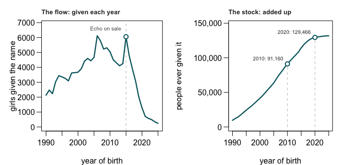

A census taken in 2020 would have shown the name **rising by 42%**. Everyone given it before the collapse was still alive to be counted, and 38,306 more were added between the censuses. **A stock absorbs a shock and a flow records it**, and that is a rule about records rather than names. Registered voters, houses and licences are counted as stocks, and each shows a change years late and smaller than it was.

## What this brief cannot tell you

**It cannot put a first name and a surname together.** They are tabulated separately, so every statement above about full names rests on multiplying two tables. The 12% correction is a floor on that error, not a measure of it.

**It cannot tell you where anybody is.** Names are not spread evenly and everything here is national, which is why the surname method needs a second file.

**It is not a source for the racial composition of the country**, and the Bureau prints that warning on both products. The shares above describe the people whose names could be used, 91.1% of the census.

**It cannot see a name that arrived recently.** To be published from 2020 a first name had to occur a hundred times in 2010 as well, so the names doing something interesting in the 2010s are missing by design.

**And these are edited names.** MICHAEL III is MICHAEL and PEÑA is PENA, which is right for a frequency table and makes the file a poor guide to the raw name field in the records you will actually join.

## What you should have learned

- A name is a distribution, not a label: 317 first names cover half the country, and 2,412 surnames, out of 53,615 and 156,621 published.
- First names are more concentrated than surnames, 70.0% against 39.7% for the top thousand, because a first name is chosen from fashion and a surname inherited.
- A full name is worth about one in 1,212,277 for a single pair, and that is optimistic: it assumes the two halves are unrelated when they are not.
- Guessing sex from a first name is 97.51% right and 7,042,013 people wrong. A surname removes 44.6% of the uncertainty about race; a first name removes 27.7%.
- A stock absorbs a shock and a flow records it: ALEXA fell 96% in births while the census count rose 42%.

## Extensions

None is answered above, and every one can be answered from the tables below.

- `explore_first.csv` gives every common first name a `pct_female`. Sort by it and read the names nearest 50. What happens to those people when a file guesses sex from a name?
- `explore_last.csv` has `pct_white` through `pct_hispanic` beside `people`. Sort by `pct_hispanic`, then by `people`. How many Americans do the strongest surnames cover?
- `race_info.csv` reports `bits_before`, `bits_after` and `pct_of_uncertainty_removed` for both kinds of name. Compare the rows. Is either enough to act on alone?
- `ssa_totals.csv` has `census_2020` beside `born_all` and `median_birth_year`. Pick a name once common and now rare, and say whether it is dying out or only ageing.
- **Stretch.** The Social Security file publishes a table for every state. Download two and compare one name in both, which is the geography this file cannot give you.

## Sources

**Data**

- U.S. Census Bureau. *Frequently Occurring First Names in the 2020 Census*, by sex and by race and Hispanic origin, and *Frequently Occurring Last Names in the 2020 Census*. Spreadsheets, no account required. https://www.census.gov/topics/population/genealogy/data/2020_names.html
- Comenetz, Joshua. *First Name Data From the 2020 Census*, 2020 Census Briefs C2020BR-13, April 2026, and *Last Name Data From the 2020 Census*, C2020BR-14. Every statement above about editing, generic entries, the question mark and the noise is theirs. https://www2.census.gov/library/publications/decennial/2020/c2020br-13.pdf
- Social Security Administration. *Beyond the Top 1000 Names*, national data, one file per year of birth, 1880 to 2025. https://www.ssa.gov/oact/babynames/limits.html

**The data itself**

All twenty-six tables are described in The data at the top of this brief. They are plain CSV, they open in a spreadsheet, and they are yours to take further: `top25.csv`, `cover.csv`, `curve.csv`, `collision.csv`, `concentration.csv`, `race_info.csv`, `race_extremes.csv`, `explore_first.csv`, `explore_last.csv`, `both_ways.csv`, `disagreement_top.csv`, `disagreement.csv`, `negatives.csv`, `negatives_top.csv`, `unisex.csv`, `sex_bands.csv`, `sex_scatter.csv`, `ssa_totals.csv`, `ssa_alexa.csv`, `ssa_births.csv`, `ssa_coverage.csv`, `ssa_explore.csv`, `ssa_newcomers.csv`, `ssa_risers.csv`, `ssa_shock.csv`, `ssa_vs_census.csv`.

**Related work**

- Word, D. L., Coleman, C. D., Nunziata, R. and Kominski, R. (2008). “Demographic Aspects of Surnames from Census 2000.” U.S. Census Bureau technical documentation, which these products descend from. https://www2.census.gov/topics/genealogy/2010surnames/surnames.pdf
- Comenetz, J. (2026). *First Name Data From the 2020 Census* (C2020BR-13) and *Last Name Data From the 2020 Census* (C2020BR-14). Census Briefs. https://www2.census.gov/library/publications/decennial/2020/c2020br-14.pdf
- Elliott, M. N. et al. (2009). “Using the Census Bureau’s surname list to improve estimates of race/ethnicity.” *Health Services and Outcomes Research Methodology* 9: 69–83, https://link.springer.com/article/10.1007/s10742-009-0047-1, the method the surnames and BISG briefs implement by hand.

Rebuild this data yourself, with an AI assistant

```
I want to rebuild two public datasets about American names from their
original sources, without any starting files. Please do the following
and show your work.

THE FIRST SOURCE. U.S. Census Bureau, "Frequently Occurring First
Names in the 2020 Census" and "Frequently Occurring Last Names in the
2020 Census", published April 2026. Spreadsheets, served plainly from
https://www2.census.gov/topics/genealogy/2020surnames/
No account or key is needed. Download two of them:
Names2020_FirstNames_Sex.xlsx (about 3 MB) and
Names2020_LastNames_RaceHispanic.xlsx (about 11 MB). In each, two
header rows sit above the column names, so skip those. Read every
column as text first and convert yourself — some count columns arrive
as text, and the proportion columns carry seventeen digits. Each file
ends with one aggregate row called ALL OTHER NAMES: it is not a name,
so leave it out when counting names, but it is people, so keep it when
totaling how many people the file covers.

THE SECOND SOURCE. Social Security Administration, "Beyond the Top
1000 Names", national data: https://www.ssa.gov/oact/babynames/names.zip
(about 8 MB) — a zip holding one text file per birth year, 1880 onward,
each row a name, a sex, and a count of babies given that name.

HOW TO DOWNLOAD THE SECOND ONE. The Social Security server refuses plain
scripted downloads. Send a browser user-agent header AND accept
compressed responses — either alone still fails. If that argument
cannot be won, download it by hand in a browser and start from the file.

WHAT TO BUILD.
1. From the census spreadsheets: how many distinct first names and how
   many distinct last names the Bureau published, and how many people
   each file covers.
2. From the Social Security files: the span of birth years, and the
   count of girls named ALEXA in 2015 against 2025.

CHECK YOUR WORK. The copies this book used were downloaded in August 2026.
If your rebuild matches them, you should find:
- 53,615 first names and 156,621 last names published
- 302,031,536 people with a first name in the census file, and
  298,898,231 with a last name
- birth years 1880 through 2025 in the Social Security file
- 6,053 girls named ALEXA in 2015, and 243 in 2025
The Social Security file grows by one year every May; a later top year
means the file was extended, not that you made an error.
```

[^1]: The Bureau’s own account of how the tables were made: Joshua Comenetz, *First Name Data From the 2020 Census*, Census Brief C2020BR-13 (April 2026), https://www2.census.gov/library/publications/decennial/2020/c2020br-13.pdf, and *Last Name Data From the 2020 Census*, C2020BR-14, https://www2.census.gov/library/publications/decennial/2020/c2020br-14.pdf.
[^2]: Census Bureau, “Disclosure Avoidance and the 2020 Census,” https://www.census.gov/programs-surveys/decennial-census/decade/2020/planning-management/process/disclosure-avoidance.html.
[^3]: The editing figures, the generic entries and the question-mark problem in the next paragraph are all reported in Comenetz, *First Name Data From the 2020 Census*, C2020BR-13.
[^4]: Massachusetts counted 7,029,917 people in the 2020 census: U.S. Census Bureau, state population totals, https://www.census.gov/data/tables/time-series/demo/popest/2020s-state-total.html.
[^5]: Amazon, “Amazon Echo Now Available to All Customers,” press release, 23 June 2015, https://press.aboutamazon.com/2015/6/amazon-echo-now-available-to-all-customers.